# Consultas espaciales en R

Martin Alalu

5/3/2020

## Calculando distancias con R

Calcular distancias es una de las funciones espaciales más útiles ya que permite ver con claridad cómo la accesibilidad a distintos bienes y servicios se distribuye desigualmente en el espacio. En tiempos de coronavirus y cuarentena ésta cuestión cobró mayor relevancia ya que al limitarse la movilidad de las personas se cristalizan los patrones espaciales, haciendo que una parte de la población tenga un acceso privilegiado a bienes y servicios mientras que otra queda se ve obligada a trasladarse más para conseguir lo mismo (y por ende se expone más al virus).

Una de las cuestiones que surgió fue la limitación para moverse a no más de 500 metros a la redonda. Analicemos esta medida en términos de acceso a un espacio verde, algo que la Organización Mundial de la Salud considera vital para el bienestar de la población. ¿Qué porción de la población de la Ciudad de Buenos Aires está a 500 metros de una plaza?

Hagamos un choropleth map que muestre con mayor intensidad aquellos radios censales que están más cerca de una plaza.

Para esto usaremos 2 datasets: radios censales y ubicación de espacios verdes, del portal de datos abiertos del Gobierno de la Ciudad de Buenos Aires.

## Explorando los datos

```r
library(tidyverse)
library(ggmap)
library(sf)


#Cargamos
radios <- st_read('https://github.com/martoalalu/clase-geo-salud/raw/master/data/caba_radios.geojson')
plazas <- st_read("https://github.com/martoalalu/clase-geo-salud/raw/master/data/espacios-verdes-catastrales.geojson")
```

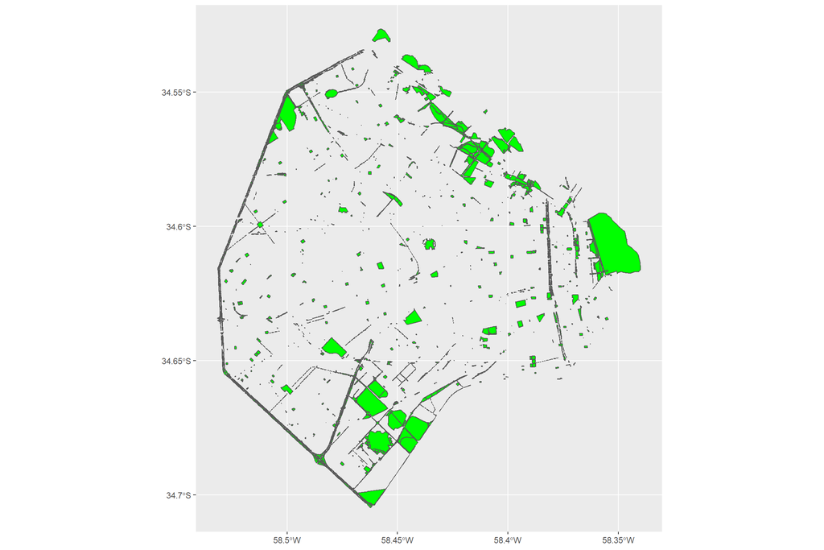

```r
ggplot() +
  geom_sf(data=plazas, fill="green")
```

Tenemos 1402 espacios verdes. Veamos qué categorías hay en el campo `TIPO_EV`.

```r
unique(plazas$TIPO_EV)
```

```
##  [1] PLAZA                       PLAZOLETA
##  [3] JARDÃ\215N                     PARQUE
##  [5] JARDÃ\215N BOTÃ\201NICO           PASEO
##  [7] CANTERO CENTRAL             CANTEROS CENTRALES
##  [9] <NA>                        GENERAL PAZ
## [11] ROTONDA                     DELLEPIANE
## [13] PATIO RECREATIVO NÂº12      PATIO PORTEÃ‘O
## [15] PATIO RECREATIVO            CANTEROS
## [17] CANTERO                     JARDINES
## [19] BOSQUE                      ESPACIO PÃšBLICO
## [21] PLAZOLETAS                  RESERVA ECOLÃ“GICA
## [23] PATIO DE JUEGOS             JARDÃ\215N ZOOLÃ“GICO
## [25] PARQUE DEPORTIVO            ESPACIO VERDE
## 25 Levels: BOSQUE CANTERO CANTERO CENTRAL CANTEROS ... ROTONDA
```

Vemos que hay espacios verdes que son canteros, plazoletas o en autopistas. Nuestro objetivo es ver el acceso a espacios verdes en los que las personas puedan distenderse y realizar algún tipo de actividad, por eso vamos a quedarnos sólo con las plazas, parques, jardín botánico, bosque, reserva ecológica, parque deportivo y espacios verdes.

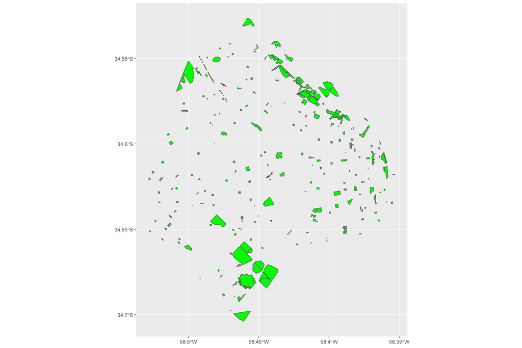

```r
plazas <- filter(plazas,TIPO_EV %in% c("PLAZA","PARQUE","JARDÍN BOTÁNICO","BOSQUE","RESERVA ECOLÓGICA","ESPACIO VERDE","PARQUE DEPORTIVO", "ESPACIO PÚBLICO"))

ggplot() +
  geom_sf(data=plazas, fill="green")
```

## Del polígono al centroide

Para calcular distancias necesitamos hacerlo de un punto exacto a otro. Necesitamos transformar nuestros polígonos (plazas y radios) en puntos exactos, para eso vamos a crear 2 nuevas capas que tengan el centroide de cada plaza y radio. Con `st_point_on_surface` nos aseguramos que el punto caiga adentro del polígono.

```r
plazas_c <- st_point_on_surface(plazas)
radios_c <- st_point_on_surface(radios)
```

Volvamos al mapa.

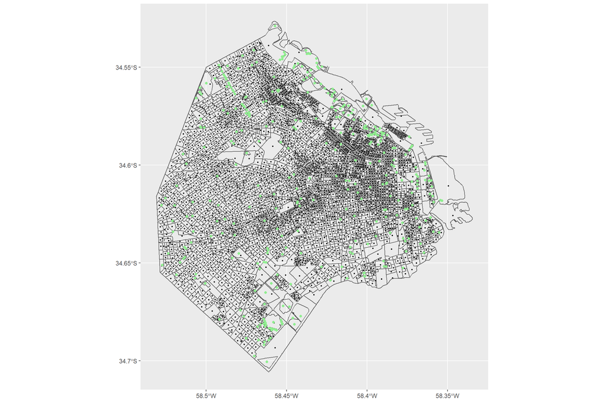

```r
ggplot() +
  geom_sf(data=radios_c, size=0.5) +
  geom_sf(data=radios, fill=NA) +
  geom_sf(data=plazas, fill=NA) +
  geom_sf(data=plazas_c, color="lightgreen")
```

## De un centroide a otro

Perfecto. Ahora bien, lo que queremos hacer es para cada centroide del radio censal encontrar el centroide de la plaza más cercana, calcular su distancia y agregarla como columna al dataframe de radios.

Se hace en pocas líneas pero vamos a explicarlo paso a paso

Primero tenemos que pedirle a R que por cada centroide de radio censal busque el centroide de la plaza más cercana. Esto lo hacemos utilizando la función `st_nearest_feature`.

```r
st_nearest_feature(radios_c,plazas_c)[1:5]
```

```
## [1] 283  12   2 153 333
```

Lo que vamos a hacer es calcular distancia elemento por elemento y para ello necesitamos tener “parejas” de radios y plazas, que por cada radio haya sí o sí una plaza asociada. Esto es sumamente útil ya que R va a agarrar el primer elemento de radios_c y va a calcular la distancia a su plaza asociada por orden, es decir uno a uno.

Entonces el siguiente paso es tener un dataframe que no sólo tenga el index de la plaza más cercana a cada radio sino tener la información geográfica (especialmente la columna geometry) para poder luego calcular la distancia propiamente dicha.

Vamos a traer la información de las plazas asociada al resultado que tuvimos con `st_nearest_feature()`.

```r
plazas_c[st_nearest_feature(radios_c, plazas_c),][1:5]
```

```
## Simple feature collection with 3554 features and 5 fields
## geometry type:  POINT
## dimension:      XY
## bbox:           xmin: -58.52777 ymin: -34.69755 xmax: -58.35335 ymax: -34.54134
## CRS:            4326
## First 10 features:
##       OBJECTID SECCION        MANZANA    PARCELA                    SMP
## 283         17     003            068        000            003-068-000
## 12          49     005            022       024a           005-022-024a
## 2            5     001            001 018a, 020b     001-001-018a, 020b
## 153        533     001           059A  000A,000B     001-059A-000A,000B
## 333         42     005 075A,075B,075C        000 005-075A,075B,075C-000
## 333.1       42     005 075A,075B,075C        000 005-075A,075B,075C-000
## 333.2       42     005 075A,075B,075C        000 005-075A,075B,075C-000
## 12.1        49     005            022       024a           005-022-024a
## 333.3       42     005 075A,075B,075C        000 005-075A,075B,075C-000
## 206       1045     012           008C        000           012-008C-000
##                          geometry
## 283   POINT (-58.37197 -34.59004)
## 12    POINT (-58.38813 -34.60519)
## 2     POINT (-58.37828 -34.60782)
## 153   POINT (-58.36943 -34.60478)
## 333   POINT (-58.38162 -34.60371)
## 333.1 POINT (-58.38162 -34.60371)
## 333.2 POINT (-58.38162 -34.60371)
## 12.1  POINT (-58.38813 -34.60519)
## 333.3 POINT (-58.38162 -34.60371)
## 206   POINT (-58.38767 -34.60916)
```

```r
nrow(plazas_c[st_nearest_feature(radios_c, plazas_c),])
```

```
## [1] 3554
```

Presten atención a la longitud de filas que devuelve este filtro, es 3554, la misma cantidad de observaciones que radios_c. Si bien estamos usando el dataframe plazas_c lo que le pedimos a R es que traiga los valores asociados sobre la función `st_nearest_feature`, que devolvía para cada index de radios_c el index de plaza_c más cercana.

Perfecto, ya tenemos un nuevo dataframe de plazas cercanas a los radios el cual está ordenado de modo tal que el primer elemento de radios_c tiene como plaza más cercana al resultado de este filtro.

Por último nos resta calcular, lo cual hacemos con `st_distance`. El primer elemento de la función es el punto de origen, en este caso el centroide del radio censal, y el segundo elemento es el centroide de la plaza más cercana, el cual obtuvimos en los pasos anteriores. Luego le decimos a R que aplique la función elemento por elemento, es decir que calcule la distancia del primer elemento de radios_c al primer elemento de `plazas_c[st_nearest_feature(radios_c, plazas_c),]`, que como sabemos es su plaza más cercana.

```r
st_distance(radios_c, plazas_c[st_nearest_feature(radios_c, plazas_c),], by_element = TRUE)[1:2]
```

```
## Units: [m]
## [1] 545.6843 270.0224
```

Perfecto! Ya tenemos el listado con las distancias calculadas! Ahora sólo resta agregarlas al dataframe de radios. Recordemos que el objetivo es hacer un choropleth map con la distancia de los radios a las plazas.

```r
radios <- radios %>%
  mutate(distancia=st_distance(radios_c, plazas_c[st_nearest_feature(radios_c, plazas_c),], by_element = TRUE)) %>%
  mutate(distancia=as.numeric(distancia))
```

Al mapa directo.

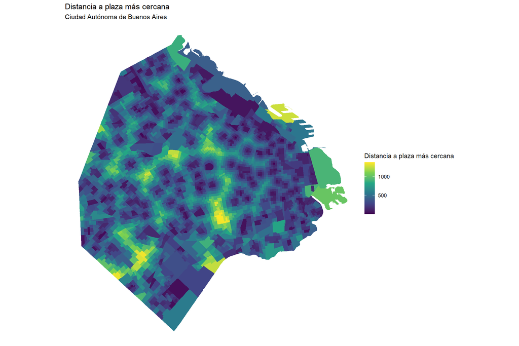

```r
ggplot() +
  geom_sf(data = radios, aes(fill = distancia), color = NA) +
  scale_fill_viridis_c() +
  labs(title = "Distancia a plaza más cercana",
       subtitle = "Ciudad Autónoma de Buenos Aires",
       fill = "Distancia a plaza más cercana")+
  theme_void()
```

Genial! Si queremos podemos quedarnos sólo con los radios censales que están a menos de 500 metros.

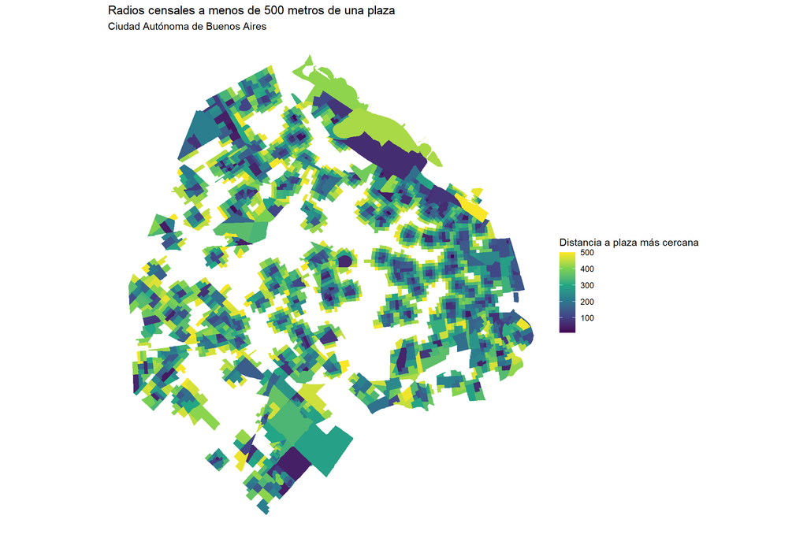

```r
ggplot() +
  geom_sf(data = filter(radios,distancia<501), aes(fill = distancia), color = NA) +
  scale_fill_viridis_c() +
  labs(title = "Radios censales a menos de 500 metros de una plaza",
       subtitle = "Ciudad Autónoma de Buenos Aires",
       fill = "Distancia a plaza más cercana")+
  theme_void()
```

Ok. Muy lindo el mapa pero ¿de cuántas personas estamos hablando?

```r
radios %>%
  group_by(distancia>500) %>%
  summarise(total=sum(POBLACION),
            pct=total/sum(radios_c$POBLACION))
```

```
## Simple feature collection with 2 features and 3 fields
## geometry type:  MULTIPOLYGON
## dimension:      XY
## bbox:           xmin: -58.53092 ymin: -34.70574 xmax: -58.33455 ymax: -34.528
## CRS:            4326
## # A tibble: 2 x 4
##   `distancia > 500`  total   pct                                   geometry
##   <lgl>              <dbl> <dbl>                         <MULTIPOLYGON [°]>
## 1 FALSE             1.85e6 0.640 (((-58.49129 -34.68228, -58.49173 -34.682~
## 2 TRUE              1.04e6 0.360 (((-58.47461 -34.6919, -58.47385 -34.6912~
```